# Cervical Cancer Risk Factors

# Author Information - Group 5

**Anirudhda Pardhi** - s3807109 , **Prerit Miglani** - s3815838 , **Ankita Vaid** - s3830243

### Affiliations

We certify that this is all our own original work. If we took any parts from elsewhere, then they were non-essential parts of the assignment, and they are clearly attributed in my submission. We will show we agree to this honor code by typing "Yes": **Yes**

# Introduction

The objective of this project is to predict the probability of cervical cancer using classification machine learning methods. The dataset was sourced from the UCI Machine Learning Repository at https://archive.ics.uci.edu/ml/datasets/Cervical+cancer+%28Risk+Factors%29# . This report is organized as follows:

1. **Overview section** describes the dataset used and the features in this dataset.
2. **Data Preparation** section covers data cleaning and data preparation steps
3. **Data Exploration and visualisation** section explores significant features and their inter-relationships using visualisation techniques.
4. **Summary and Conclusions** section describes the major important impofmation extraced from dataset.

# Overview

### Data Source

Data was downloaded in csv format from UCI Machine Learning Repository.The dataset has 858 observations. Characteristics of Dataset is Multivariate. Datasets consist of 36 number of attributes which contains continuous and categorical datatype attributes. In this project, we will split training and test dataset within this dataset.

### Project Objective

Our goal focuses on the prediction of indicators/diagnosis of cervical cancer.There are 4 target variables in the dataset which as combination will gives us level of risk in predicting cancer successfully.

### Target Feature

Our target features are **Hinselmann, Schiller, Citology and Biopsy** which are categorical features. Hence, our project is based on a classification problem.

### Descriptive Features

Boolean features are categorical attributes where 0 indicates No and 1 indicates Yes . Other integer variable are continuous in nature.

# Data Preparation

Importing the required modules and reading the csv file in pandas

```python
# Importing required modules
import pandas as pd
import os
import matplotlib.pyplot as plt
import numpy as np
import math
import seaborn as sns
```

```python
#importing the csv file
abc = pd.read_csv('risk_factors_cervical_cancer.csv', header=0)
```

```python
#Copying orignal dataframe to another for reference
df=abc.copy()
```

```python
#checking first 5 records of dataframe using head function
df.head()
```

|  | Age | Number of sexual partners | First sexual intercourse | Num of pregnancies | Smokes | Smokes (years) | Smokes (packs/year) | Hormonal Contraceptives | Hormonal Contraceptives (years) | IUD | ... | STDs: Time since first diagnosis | STDs: Time since last diagnosis | Dx:Cancer | Dx:CIN | Dx:HPV | Dx | Hinselmann | Schiller | Citology | Biopsy |
| --- | --- | --- | --- | --- | --- | --- | --- | --- | --- | --- | --- | --- | --- | --- | --- | --- | --- | --- | --- | --- | --- |
| 0 | 18 | 4.0 | 15.0 | 1.0 | 0.0 | 0.0 | 0.0 | 0.0 | 0.0 | 0.0 | ... | ? | ? | 0 | 0 | 0 | 0 | 0 | 0 | 0 | 0 |
| 1 | 15 | 1.0 | 14.0 | 1.0 | 0.0 | 0.0 | 0.0 | 0.0 | 0.0 | 0.0 | ... | ? | ? | 0 | 0 | 0 | 0 | 0 | 0 | 0 | 0 |
| 2 | 34 | 1.0 | ? | 1.0 | 0.0 | 0.0 | 0.0 | 0.0 | 0.0 | 0.0 | ... | ? | ? | 0 | 0 | 0 | 0 | 0 | 0 | 0 | 0 |
| 3 | 52 | 5.0 | 16.0 | 4.0 | 1.0 | 37.0 | 37.0 | 1.0 | 3.0 | 0.0 | ... | ? | ? | 1 | 0 | 1 | 0 | 0 | 0 | 0 | 0 |
| 4 | 46 | 3.0 | 21.0 | 4.0 | 0.0 | 0.0 | 0.0 | 1.0 | 15.0 | 0.0 | ... | ? | ? | 0 | 0 | 0 | 0 | 0 | 0 | 0 | 0 |

5 rows × 36 columns

# Data Cleaning and preprocessing

We are initially checking datatypes of attribues if they match with description of orignal data source.

```python
#checking the datatypes of attributes
df.dtypes
```

```
Age                                    int64
Number of sexual partners             object
First sexual intercourse              object
Num of pregnancies                    object
Smokes                                object
Smokes (years)                        object
Smokes (packs/year)                   object
Hormonal Contraceptives               object
Hormonal Contraceptives (years)       object
IUD                                   object
IUD (years)                           object
STDs                                  object
STDs (number)                         object
STDs:condylomatosis                   object
STDs:cervical condylomatosis          object
STDs:vaginal condylomatosis           object
STDs:vulvo-perineal condylomatosis    object
STDs:syphilis                         object
STDs:pelvic inflammatory disease      object
STDs:genital herpes                   object
STDs:molluscum contagiosum            object
STDs:AIDS                             object
STDs:HIV                              object
STDs:Hepatitis B                      object
STDs:HPV                              object
STDs: Number of diagnosis              int64
STDs: Time since first diagnosis      object
STDs: Time since last diagnosis       object
Dx:Cancer                              int64
Dx:CIN                                 int64
Dx:HPV                                 int64
Dx                                     int64
Hinselmann                             int64
Schiller                               int64
Citology                               int64
Biopsy                                 int64
dtype: object
```

# Statastical description of data

Here we are checking statastics for all the attribues of dataframe

```python
df.describe()
```

|  | Age | STDs: Number of diagnosis | Dx:Cancer | Dx:CIN | Dx:HPV | Dx | Hinselmann | Schiller | Citology | Biopsy |
| --- | --- | --- | --- | --- | --- | --- | --- | --- | --- | --- |
| count | 858.000000 | 858.000000 | 858.000000 | 858.000000 | 858.000000 | 858.000000 | 858.000000 | 858.000000 | 858.000000 | 858.000000 |
| mean | 26.820513 | 0.087413 | 0.020979 | 0.010490 | 0.020979 | 0.027972 | 0.040793 | 0.086247 | 0.051282 | 0.064103 |
| std | 8.497948 | 0.302545 | 0.143398 | 0.101939 | 0.143398 | 0.164989 | 0.197925 | 0.280892 | 0.220701 | 0.245078 |
| min | 13.000000 | 0.000000 | 0.000000 | 0.000000 | 0.000000 | 0.000000 | 0.000000 | 0.000000 | 0.000000 | 0.000000 |
| 25% | 20.000000 | 0.000000 | 0.000000 | 0.000000 | 0.000000 | 0.000000 | 0.000000 | 0.000000 | 0.000000 | 0.000000 |
| 50% | 25.000000 | 0.000000 | 0.000000 | 0.000000 | 0.000000 | 0.000000 | 0.000000 | 0.000000 | 0.000000 | 0.000000 |
| 75% | 32.000000 | 0.000000 | 0.000000 | 0.000000 | 0.000000 | 0.000000 | 0.000000 | 0.000000 | 0.000000 | 0.000000 |
| max | 84.000000 | 3.000000 | 1.000000 | 1.000000 | 1.000000 | 1.000000 | 1.000000 | 1.000000 | 1.000000 | 1.000000 |

# Data insight

To get more insight about our dataset we are analysing what different types of values are present in each attribute.

```python
#checking for unique values present in all attributes
for a in df.columns.difference(['Age']):
    print(a)
    print(df[a].value_counts(dropna = False))
```

```
Biopsy
0    803
1     55
Name: Biopsy, dtype: int64
Citology
0    814
1     44
Name: Citology, dtype: int64
Dx
0    834
1     24
Name: Dx, dtype: int64
Dx:CIN
0    849
1      9
Name: Dx:CIN, dtype: int64
Dx:Cancer
0    840
1     18
Name: Dx:Cancer, dtype: int64
Dx:HPV
0    840
1     18
Name: Dx:HPV, dtype: int64
First sexual intercourse
15.0    163
17.0    151
18.0    137
16.0    121
14.0     79
19.0     60
20.0     37
13.0     25
21.0     20
22.0      9
23.0      9
?         7
26.0      7
12.0      6
27.0      6
```

[output cut: 282 more lines]

```
0.5              3
13.0             3
19.0             3
12.0             3
22.0             2
20.0             1
37.0             1
34.0             1
28.0             1
21.0             1
18.0             1
32.0             1
0.16             1
24.0             1
Name: Smokes (years), dtype: int64
```

### Dropping insignificant attributes

We are dropping 2 columns which were insignificant and had lots of missing values

```python
df.drop(['STDs: Time since first diagnosis','STDs: Time since last diagnosis'],axis=1,inplace=True)
```

### Replacing corrupt data value with null values

We are replacing character '?' with null values for all numerical attribues.

```python
df = df.replace('?', np.NaN)
```

# Appropriate datatype conversion

We are converting the object datatype attributes to numerical float datatype which were continuous in nature and checking if all the conversion are properly applied. All the categorical datatypes are divided into integer 0 or 1 where 0 indicates No and 1 indicates Yes.

```python
#Converting the appropriate attribues datatype from object to numeric
df_cat=df.select_dtypes(include="object")
df_cat1=df_cat.apply(pd.to_numeric)
df_cat1.columns
```

```
Index(['Number of sexual partners', 'First sexual intercourse',
       'Num of pregnancies', 'Smokes', 'Smokes (years)', 'Smokes (packs/year)',
       'Hormonal Contraceptives', 'Hormonal Contraceptives (years)', 'IUD',
       'IUD (years)', 'STDs', 'STDs (number)', 'STDs:condylomatosis',
       'STDs:cervical condylomatosis', 'STDs:vaginal condylomatosis',
       'STDs:vulvo-perineal condylomatosis', 'STDs:syphilis',
       'STDs:pelvic inflammatory disease', 'STDs:genital herpes',
       'STDs:molluscum contagiosum', 'STDs:AIDS', 'STDs:HIV',
       'STDs:Hepatitis B', 'STDs:HPV'],
      dtype='object')
```

```python
#Checking if object datatype has been successfully converted into float datatype
df_cat1.dtypes
```

```
Number of sexual partners             float64
First sexual intercourse              float64
Num of pregnancies                    float64
Smokes                                float64
Smokes (years)                        float64
Smokes (packs/year)                   float64
Hormonal Contraceptives               float64
Hormonal Contraceptives (years)       float64
IUD                                   float64
IUD (years)                           float64
STDs                                  float64
STDs (number)                         float64
STDs:condylomatosis                   float64
STDs:cervical condylomatosis          float64
STDs:vaginal condylomatosis           float64
STDs:vulvo-perineal condylomatosis    float64
STDs:syphilis                         float64
STDs:pelvic inflammatory disease      float64
STDs:genital herpes                   float64
STDs:molluscum contagiosum            float64
STDs:AIDS                             float64
STDs:HIV                              float64
STDs:Hepatitis B                      float64
STDs:HPV                              float64
dtype: object
```

```python
#Checking for (categorical)attributes with integer datatypes
df_num=df.select_dtypes(include="number")
df_num.dtypes
```

```
Number of sexual partners             float64
First sexual intercourse              float64
Num of pregnancies                    float64
Smokes                                float64
Smokes (years)                        float64
Smokes (packs/year)                   float64
Hormonal Contraceptives               float64
Hormonal Contraceptives (years)       float64
IUD                                   float64
IUD (years)                           float64
STDs                                  float64
STDs (number)                         float64
STDs:condylomatosis                   float64
STDs:cervical condylomatosis          float64
STDs:vaginal condylomatosis           float64
STDs:vulvo-perineal condylomatosis    float64
STDs:syphilis                         float64
STDs:pelvic inflammatory disease      float64
STDs:genital herpes                   float64
STDs:molluscum contagiosum            float64
STDs:AIDS                             float64
STDs:HIV                              float64
STDs:Hepatitis B                      float64
STDs:HPV                              float64
Age                                     int64
STDs: Number of diagnosis               int64
Dx:Cancer                               int64
Dx:CIN                                  int64
Dx:HPV                                  int64
Dx                                      int64
Hinselmann                              int64
Schiller                                int64
Citology                                int64
Biopsy                                  int64
dtype: object
```

```python
#Concatinating the float dataype(continuous variable) dataframe and integer dataype(categorical variable) dataframe
df=pd.concat([df_cat1,df_num],axis=1,join="inner")
```

# Handling null values

In order to handle null values across dataset we are preparing 2 types of list:

- List of numerical continuous attributes
- List of categorical attributes

We are filling missing values in **continuous variables** with their respective feature's **mean** by looping through list of numerical continuous attributes.

```python
#List of numerical continuous attributes
continuous_df = ['Age', 'Number of sexual partners', 'First sexual intercourse','Num of pregnancies', 'Smokes (years)',
                'Smokes (packs/year)','Hormonal Contraceptives (years)','IUD (years)','STDs (number)']
```

```python
#List of categorical attributes
categorical_df = ['Smokes','Hormonal Contraceptives','IUD','STDs','STDs:condylomatosis','STDs:cervical condylomatosis',
                  'STDs:vaginal condylomatosis','STDs:vulvo-perineal condylomatosis', 'STDs:syphilis',
                  'STDs:pelvic inflammatory disease', 'STDs:genital herpes','STDs:molluscum contagiosum', 'STDs:AIDS',
                  'STDs:HIV','STDs:Hepatitis B', 'STDs:HPV', 'STDs: Number of diagnosis','Dx:Cancer', 'Dx:CIN',
                  'Dx:HPV', 'Dx', 'Hinselmann', 'Schiller','Citology', 'Biopsy']
```

```python
#Filling missing values in categorical variables
for i in categorical_df:

    df[i] = df[i].fillna(1.0)
```

```python
#Filling missing values in continuous variables
for i in continuous_df:
    j = round(df[i].mean(),1)
    df[i] = df[i].fillna(j)
```

### Re-checking null values presence

```python
#Checking for presence of null values in dataframe
df.isnull().sum()
```

```
Number of sexual partners             0
First sexual intercourse              0
Num of pregnancies                    0
Smokes                                0
Smokes (years)                        0
Smokes (packs/year)                   0
Hormonal Contraceptives               0
Hormonal Contraceptives (years)       0
IUD                                   0
IUD (years)                           0
STDs                                  0
STDs (number)                         0
STDs:condylomatosis                   0
STDs:cervical condylomatosis          0
STDs:vaginal condylomatosis           0
STDs:vulvo-perineal condylomatosis    0
STDs:syphilis                         0
STDs:pelvic inflammatory disease      0
STDs:genital herpes                   0
STDs:molluscum contagiosum            0
STDs:AIDS                             0
STDs:HIV                              0
STDs:Hepatitis B                      0
STDs:HPV                              0
Age                                   0
STDs: Number of diagnosis             0
Dx:Cancer                             0
Dx:CIN                                0
Dx:HPV                                0
Dx                                    0
Hinselmann                            0
Schiller                              0
Citology                              0
Biopsy                                0
dtype: int64
```

# Data Exploration and Visualisation

Our dataset is clean and we are now proceeding with the visualisation part.

# One-variable plots

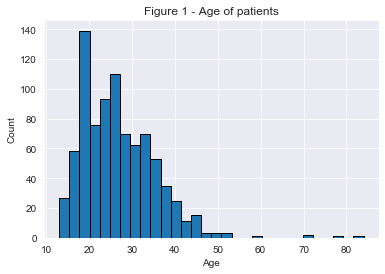

```python
#One-variable Visualisation : Histogram - Figure 1
df['Age'].plot(kind='hist',bins=30,edgecolor='black')
plt.title('Figure 1 - Age of patients')
plt.xlabel('Age')
plt.ylabel('Count')
```

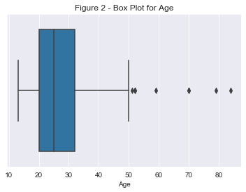

```
Mean age = 26.82051282051282
```

```python
##One-variable Visualisation : Boxplot - Figure 2
sns.boxplot(df['Age']).set_title('Figure 2 - Box Plot for Age', fontsize = 12)
plt.show();
print('Mean age =',df['Age'].mean())
```

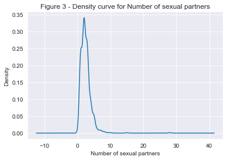

```python
#One-variable Visualisation : Density curve - Figure 3
df['Number of sexual partners'].plot(kind='density')
plt.title('Figure 3 - Density curve for Number of sexual partners')
plt.xlabel('Number of sexual partners')
```

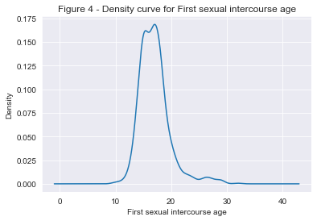

```python
#One-variable Visualisation : Density curve - Figure 4
df['First sexual intercourse'].plot(kind='density')
plt.title('Figure 4 - Density curve for First sexual intercourse age')
plt.xlabel('First sexual intercourse age')
```

## Two-variable plots

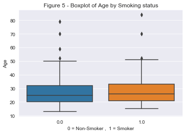

```python
#Two-variable Visualisation : Boxplot - Figure 5
sns.boxplot(df['Smokes'], df['Age']);
plt.title('Figure 5 - Boxplot of Age by Smoking status', fontsize = 12)
plt.xlabel('0 = Non-Smoker ,  1 = Smoker')
plt.show();
```

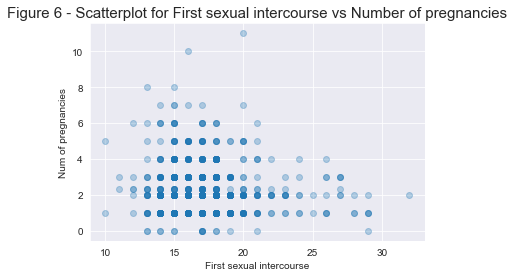

```python
#Two-variable Visualisation : Scatterplot - Figure 6
plt.scatter(df['First sexual intercourse'], df['Num of pregnancies'], alpha = 0.3)
plt.title('Figure 6 - Scatterplot for First sexual intercourse vs Number of pregnancies', fontsize = 15)
plt.xlabel('First sexual intercourse')
plt.ylabel('Num of pregnancies')
plt.show();
```

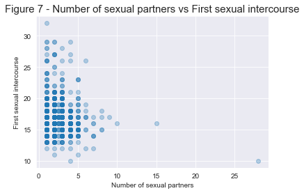

```python
#Two-variable Visualisation : Scatterplot - Figure 7
plt.scatter(df['Number of sexual partners'], df['First sexual intercourse'], alpha = 0.3)
plt.title('Figure 7 - Number of sexual partners vs First sexual intercourse', fontsize = 15)
plt.xlabel('Number of sexual partners')
plt.ylabel('First sexual intercourse')
plt.show();
```

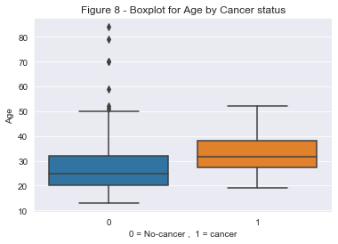

```python
#Two-variable Visualisation : Boxplot - Figure 8
sns.boxplot(df['Dx:Cancer'], df['Age']);
plt.title('Figure 8 - Boxplot for Age by Cancer status', fontsize = 12)
plt.xlabel('0 = No-cancer ,  1 = cancer')
plt.show();
```

## Three-variable plots

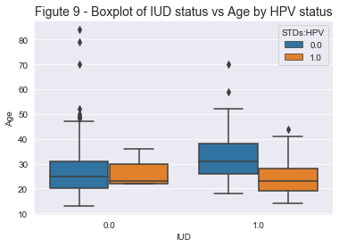

```python
#Three-variable Visualisation : Boxplot - Figure 9
sns.boxplot(df['IUD'], df['Age'], hue = df['STDs:HPV'])
plt.title('Figute 9 - Boxplot of IUD status vs Age by HPV status', fontsize = 14)
plt.show();
```

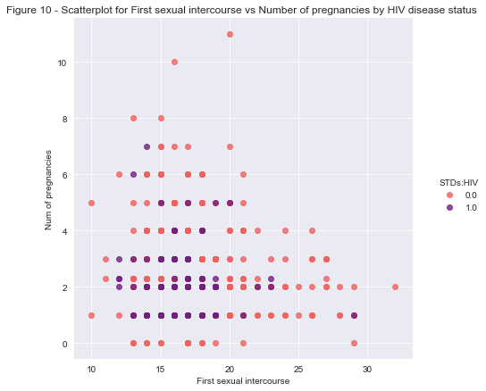

```python
#Three-variable Visualisation : Scatterplot - Figure 10
sns.set_style('darkgrid')
sns.lmplot('First sexual intercourse','Num of pregnancies',data=df, hue='STDs:HIV',palette='magma_r',height=6,aspect=1,fit_reg=False)
plt.title('Figure 10 - Scatterplot for First sexual intercourse vs Number of pregnancies by HIV disease status ', fontsize = 12)
plt.show();
```

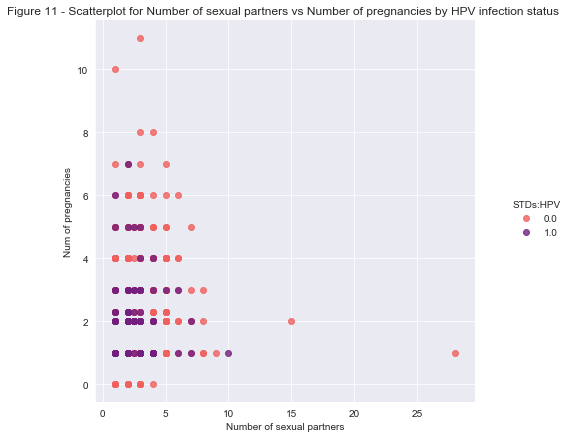

```python
#Three-variable Visualisation : Scatterplot - Figure 11
sns.set_style('darkgrid')
sns.lmplot('Number of sexual partners','Num of pregnancies',data=df, hue='STDs:HPV',palette='magma_r',height=6,aspect=1,fit_reg=False)
plt.title('Figure 11 - Scatterplot for Number of sexual partners vs Number of pregnancies by HPV infection status ', fontsize = 12)
plt.show();
```

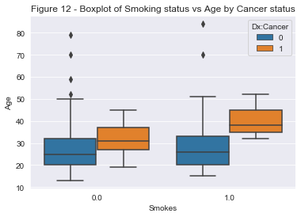

```python
#Three-variable Visualisation : Scatterplot - Figure 12
sns.boxplot(df['Smokes'], df['Age'], hue = df['Dx:Cancer'])
plt.title('Figure 12 - Boxplot of Smoking status vs Age by Cancer status', fontsize = 12)
plt.show();
```

# Target variable visualisation

We are plotting bar graphs for Age vs Number of sexual partners by Target variables. Our target variables are Hinselmann, Schiller,Citology and Biopsy.

```python
targettest_df = ['Hinselmann', 'Schiller','Citology', 'Biopsy']
```

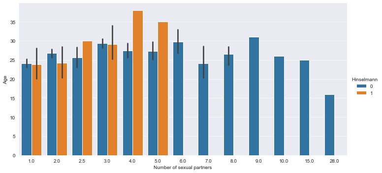

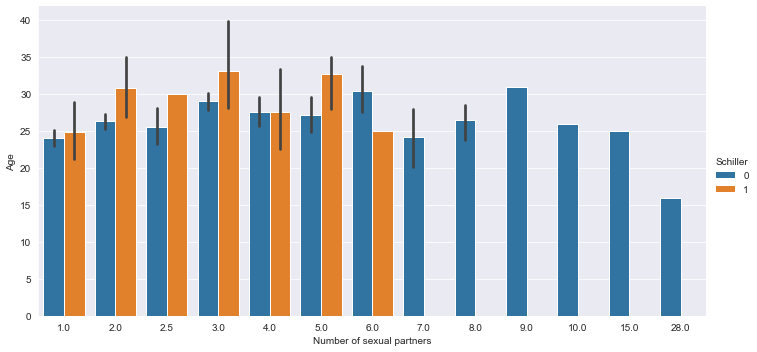

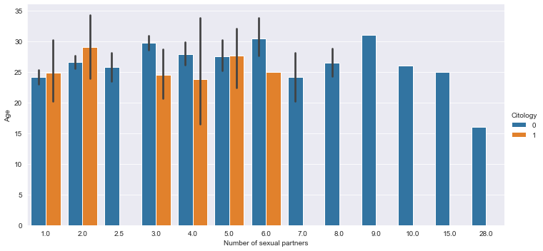

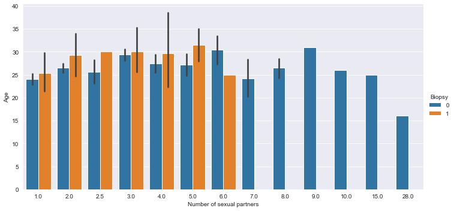

```python
for i in targettest_df:

  sns.catplot(x='Number of sexual partners',y='Age',hue=i,data=df,aspect=2.0,kind='bar');
```

# Summary and Conclusions

There are 4 categorical target variables in the dataset Hinselmann + Schiller + Citology + Biopsy which as combination gives us level of risk in probablity of cancer.

## Refrences

- UCI Machine Learning Repository [online]. Available at https://archive.ics.uci.edu/ml/datasets/Cervical+cancer+%28Risk+Factors%29#
- Relevant Papers: Kelwin Fernandes, Jaime S. Cardoso, and Jessica Fernandes. 'Transfer Learning with Partial Observability Applied to Cervical Cancer Screening.' Iberian Conference on Pattern Recognition and Image Analysis. Springer International Publishing, 2017.